# Norm

The **norm**, **magnitude**, or **length** of a vector is analogous to the absolute value of a scalar. There are many different ways to define the norm. In this class we will nearly always use the *Euclidean norm*, which is defined for the $n$-vector $\mathbf v$ as

$$ ||\mathbf v|| = \sqrt{v_1^2 + \cdots + v_n^2} . $$

A **unit vector** is any vector with norm equal to 1.

```python
import numpy as np
import matplotlib.pyplot as plt

# the norm() function is found in the linalg module of numpy
v = np.array([1,2,3])
print("||v|| =", np.linalg.norm(v))
```

```
||v|| = 3.7416573867739413
```

# Scalar-vector multiplication

Multiplying a vector by a scalar means multiplying each element separately by the scalar, which results in a new vector:

$$ \alpha \mathbf v = (\alpha v_1, \cdots, \alpha v_n) $$

Another way to think about this operation is that we are simply changing the magnitude of $\mathbf v$ by stretching or compressing it. If $|\alpha| > 1$, $\mathbf v$ is stretched; if $|\alpha| < 1$, $\mathbf v$ is compressed. If $\alpha < 0$, the direction of $\mathbf v$ is flipped. Any of these cases can be visualized in 2-vectors and 3-vectors.

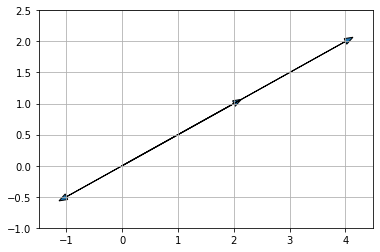

```python
a = np.array([2,1])
b = 2*a
c = -0.5*a

plt.arrow(0, 0, a[0], a[1], head_width=.1)
plt.arrow(0, 0, b[0], b[1], head_width=.1)
plt.arrow(0, 0, c[0], c[1], head_width=.1)
plt.axis([-1.5,4.5,-1,2.5])
plt.grid()
```

A common operation is to compute a unit vector $\mathbf u$ in the same direction as an arbitrary vector $\mathbf v$. To do so, we can simply divide $\mathbf v$ by its norm:

$$\mathbf u = \frac{\mathbf v}{||\mathbf v||}$$

The following are properties of scalar-vector multiplication:

- Associativity: $\alpha (\beta \mathbf a) = (\alpha \beta) \mathbf a$
- (Existence of) Identity: $1\mathbf a = \mathbf a$
- Distributivity over scalar addition: $(\alpha+\beta) \mathbf a = \alpha \mathbf a + \beta \mathbf a$

# Vector addition

*Vector addition* can be applied to two or more given vectors of the same dimension. The sum of two vectors is the sum of each of the vectors' corresponding elements, which is a new vector of the same size:

$$\mathbf v + \mathbf w = (v_1+w_1, \cdots, v_n+w_n)$$

To visualize this in 2 and 3 dimensions, you can imagine taking the tail of the vector $\mathbf w$ and moving it so that it is coincident with the head of $\mathbf v$. The sum is the new vector whose tail is coincident with the tail of $\mathbf v$ and whose head is coincident with the head of $\mathbf w$.

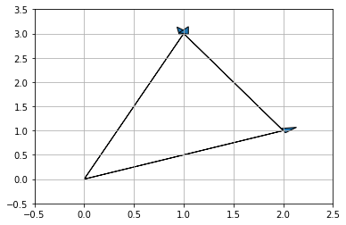

```python
a = np.array([2,1])
b = np.array([-1,2])
c = a + b

plt.arrow(0, 0, a[0], a[1], head_width=.1)
plt.arrow(a[0], a[1], b[0], b[1], head_width=.1)
plt.arrow(0, 0, c[0], c[1], head_width=.1)
plt.axis([-0.5,2.5,-0.5,3.5])
plt.grid()
```

The following are properties of vector addition:

- Commutativity: $\mathbf a + \mathbf b = \mathbf b + \mathbf a$
- Associativity: $(\mathbf a + \mathbf b) + \mathbf c = \mathbf a + (\mathbf b + \mathbf c)$
- (Existence of) Identity: $\mathbf a + \mathbf 0 = \mathbf a$
- (Existence of) Inverse: $\mathbf a + (-\mathbf a) = \mathbf 0$
- Distributivity over scalar multiplication: $\alpha (\mathbf a + \mathbf b) = \alpha \mathbf a + \alpha \mathbf b$

# Linear combinations

Suppose we are given a set of vectors $\mathbf v_1, \mathbf v_2, \ldots$. If we consider scaling each one by some arbitrary scalar and then adding the scaled vectors together, we obtain a **linear combination** $\mathbf v$ of the original vectors:

$$\mathbf v = c_1 \mathbf v_1 + c_2 \mathbf v_2 + \cdots = \sum_i c_i \mathbf v_i $$

We often think about the set of *all* linear combinations of a set of vectors. This is called the **span** of a set of vectors:

$$ \text{Span} \{\mathbf v_1, \mathbf v_2, \ldots\} = \left\{ \sum_i c_i \mathbf v_i \mid c_i \in \mathbb R \right\} $$

Visualizing spans of vectors (again in 2D and 3D) can help us better understand them. The span of a single vector $\mathbf v$ is just the set of all scalar multiples of it. This can be represented as a *line* through the origin and the point defined by the vector.

## Spanning two vectors

The visualization of the span of two vectors $\mathbf v_1$ and $\mathbf v_2$ may depend on the vectors themselves. If $\mathbf v_1$ and $\mathbf v_2$ are not multiples of each other (if they do not lie in each other's spans), then $\text{Span}\{\mathbf v_1, \mathbf v_2\}$ forms a *plane*. If these are 2-vectors, this is the entire coordinate plane; if these are 3-vectors, this forms some plane embedded in 3D space. On the other hand, if these vectors *are* multiples of each other, then $\text{Span}\{\mathbf v_1, \mathbf v_2\} = \text{Span}\{\mathbf v_1\} = \text{Span}\{\mathbf v_2\}$, which is just the line through the origin and the points defined by the two vectors.

## Spanning three vectors

The span of three vectors $\mathbf v_1$, $\mathbf v_2$, and $\mathbf v_3$ gets even trickier, and we'll just present the high-level idea here before reserving the algebraic generalization for the discussion on linear independence. First consider $\text{Span}\{\mathbf v_1, \mathbf v_2\}$. If this is a line, then we must consider whether $\mathbf v_3$ also lies on this line. If it does, then the span of all three is still the same line; if it does not, then we have a plane $\text{Span}\{\mathbf v_1, \mathbf v_3\} = \text{Span}\{\mathbf v_2, \mathbf v_3\}$ as before.

Alternatively, if $\text{Span}\{\mathbf v_1, \mathbf v_2\}$ is a plane, we consider whether $\mathbf v_3$ lies in this plane. If it does, then $\text{Span}\{\mathbf v_1, \mathbf v_2, \mathbf v_3\} = \text{Span}\{\mathbf v_1, \mathbf v_2\}$. Note that this is guaranteed if these vectors are 2-vectors. If $\mathbf v_3$ does *not* lie in this plane, then $\text{Span}\{\mathbf v_1, \mathbf v_2, \mathbf v_3\}$ can be thought of as the full 3-dimensional space. It is possible to obtain *any* 3-vector using a linear combination of $\mathbf v_1$, $\mathbf v_2$, and $\mathbf v_3$.

# Dot product

There are several different ways to *multiply* two $n$-vectors $\mathbf v$ and $\mathbf w$ together. By far the most important is the **dot product**, which is defined as the elementwise product of each of $\mathbf v$ and $\mathbf w$, followed by a sum over the resultant products. The output is thus a *scalar*.

$$ \mathbf v \cdot \mathbf w = v_1 w_1 + v_2 w_2 + \cdots = \sum_i^n v_i w_i $$

You may also see the dot product written as $\mathbf v^\top \mathbf w$ or $\langle \mathbf v, \mathbf w \rangle$. The former is really a *matrix product* of a row vector with a column vector. The latter is usually reserved for *inner products*, which generalizes the notion of dot products.

```python
v = np.array([1,2,3])
w = np.array((3,2,1))

# there are several different ways to compute dot products in numpy
print("dot product of v and w is", np.dot(v,w))     # simplest function is dot()
print("dot product of v and w is", np.inner(v,w))   # inner() is very similar
print("dot product of v and w is", np.matmul(v,w))  # matmul() can be generalized to matrix multiplication
print("dot product of v and w is", v@w)             # shorthand for matmul
```

```
dot product of v and w is 10
dot product of v and w is 10
dot product of v and w is 10
dot product of v and w is 10
```

The following are properties of dot products:

- Commutativity: $\mathbf a \cdot \mathbf b = \mathbf b \cdot \mathbf a$
- Distributivity over vector addition: $\mathbf a \cdot (\mathbf b + \mathbf c) = \mathbf a \cdot \mathbf b + \mathbf a \cdot \mathbf c$

The norm can be defined as the square root of the dot product of a vector with itself:

$$ ||\mathbf v|| = \sqrt{\mathbf v \cdot \mathbf v} $$

We can also define the *angle* $\theta$ between two vectors using the dot product with the relationship

$$\mathbf v \cdot \mathbf w = ||\mathbf v|| ||\mathbf w|| \cos \theta.$$

Suppose we define $\theta$ between $-\pi$ and $\pi$. If $|\theta| < \pi/2$, then the angle is *acute* and the dot product is positive. If $\pi/2 < |\theta| < \pi$, then the angle is *obtuse* and the dot product is negative. Finally, if $\theta = \pi/2$ then the dot product is $0$ and the vectors are *orthogonal*.

Since $|\cos\theta| \leq 1$, the *Cauchy-Schwarz inequality* says that $|\mathbf v \cdot \mathbf w| \leq ||\mathbf v|| ||\mathbf w||$.

# Other vector products

We summarize other types of vector products. The **Hadamard product** of two $n$-vectors is purely an elementwise product. That is, the output is the vector computed by the dot product *before* the final summation.

$$ \mathbf v \circ \mathbf w = (v_1 w_1, v_2 w_2, \cdots, v_n w_n) $$

This does not appear very often in the theory of linear algebra, but it can be very useful for data manipulation in programs.

```python
print(v*w)  # hadamard product simply uses the * operator
```

```
[3 4 3]
```

The **outer product** multiplies a column vector by a row vector (reverse ordering of the dot product). The vectors may have different dimensions, for example $m$ and $n$. We can view this as a matrix operation, and the result is a $m \times n$ matrix. We will review this later on, but we will show the definition here:

$$ \mathbf v \mathbf w^\top = \begin{bmatrix} v_1 w_1 & v_1 w_2 & \cdots & v_1 w_n \\ v_2 w_1 & v_2 w_2 & \cdots & v_2 w_n \\ \vdots & \vdots & \ddots & \vdots \\ v_m w_1 & v_m w_2 & \cdots & v_m w_n \end{bmatrix} $$

```python
print(np.outer(v,w))
```

```
[[3 2 1]
 [6 4 2]
 [9 6 3]]
```

The *cross product* is defined for two 3-dimensional vectors. It is used mostly in geometry and you may have seen it before. We will not use the cross product in this class.